# Lab 2, CP 4: Análise completa

## 1. Dataset

Os dados utilizados durante esta análise foram coletados por meio do registro de logs dos eventos ocorridos durante interações de usuários no site do Wikipédia no período entre 01 a 08 de março no ano 2016. Estes dados foram disponibilizados pela organização sem fins lucrativos que gerencia o site da Wikipédia, a Wikimedia Foundation.

```r
buscas = read_csv(here::here("data/search_data.csv"))
```

A coleta dos dados teve objetivo de identificar diferenças no uso do site por dois diferentes grupos (a e b), cada grupo utilizava um diferente modo de buscar por conteúdo no site. A tabela abaixo apresenta a quantidade de sessões para cada grupo estudado.

```r
buscas %>%
    group_by(grupo = group) %>%
    summarise(quantidade_sessao = n())
```

| grupo | quantidade_sessao |
| --- | --- |
| a | 29427 |
| b | 38601 |

Nesse contexto, com o objetivo investigar as diferentes formas de buscar por conteúdos no site, eram registradas informações durante a realização de cada evento pelo usuário, possibilitando a obtenção de conhecimentos sobre a ação realizada (busca, clique no resultado da busca, tempo de permanência na página), quantos resultados foram retornados nas buscas, qual a posição o usuário clicou ao visitar uma página e etc.

Para esta análise, os dados foram agrupados considerando cada sessão existente e sumarizando as informações de cada evento no nível de sessão. Desta forma, esta pesquisa propõe responder às seguintes perguntas:

1. Qual é a taxa de cliques nos diferentes dias? Como isso varia nos dois grupos?
2. Considerando os resultados das buscas, o resultado de qual posição os usuário tendem a clicar? Como isso muda durantes os diferentes dias?
3. Qual é a taxa de buscas com zero resultados? Como isso varia nos dois grupos?
4. Considerando o tempo aproximado de duração da sessão de cada usuário como o registro do primeiro e último evento, os usuários com maior número de cliques tendem a ter um tempo de sessão maior? Como isso varia nos dois grupos?

A fim de responder essas perguntas, foram identificados alguns pontos a serem considerados durante a análise:

- *Em todos os 8 dias existem sessões contidas entre as faixas de 1h a 23:59h (24h)*;
- *Existem sessões que não possuem busca ou páginas visitadas que não apresentam a posição que resultou em seu acesso:* Estes dois contextos, foram consideradas como inatividade do usuário por mais de 10 min, o que resultou na criação de novas sessões com tais informações ausentes.

Ainda nesse contexto, com o objetivo de responder as perguntas foram utilizadas as seguintes variáveis:

- *num_clicks:* número de ocorrência do evento de visitar página;
- *taxa de cliques:* proporção de cliques, nas sessões com pelo menos uma página visitada;
- *session_start_date:* data e hora do primeiro evento registrado na sessão;
- *group:* grupo ao qual a sessão pertence, variando entre a e b;
- *position_clicked:* mediana da posição escolhida pelo usuário durantes visitas de páginas em cada sessão.
- *session_durantion_sec:* tempo de duração da sessão em segundos.

## 2. Taxa de cliques no decorrer dos dias

Considerando a taxa de cliques diária como a proporção de cliques em todas as sessões em cada dia e divindo os dados entre os grupos a e b, foi investigada a primeira pergunta. Com base nessa análise, a Figura 1 foi produzida.

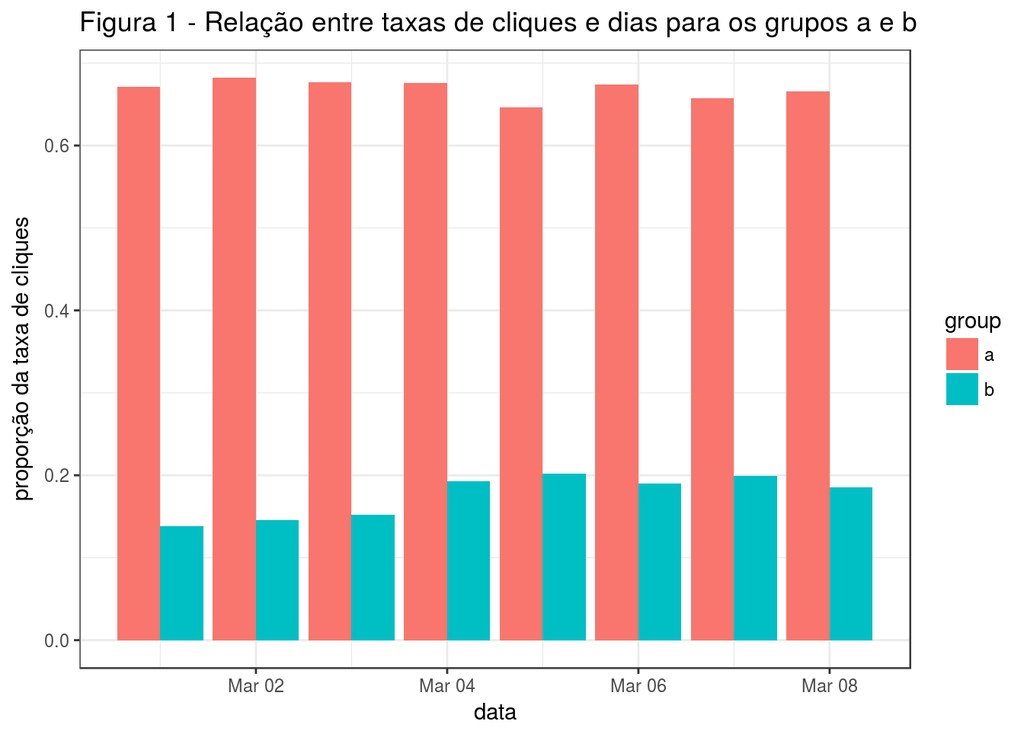

```r
buscas %>%
    group_by(data = as.Date(session_start_date), group) %>%
    summarise(taxa_cliques = sum(num_clicks > 0)/n()) %>%
    ggplot(aes(x = as.Date(data), y = taxa_cliques, fill = group)) +
    geom_col(position = "dodge") +
    scale_x_date('data', date_labels = "%b %d") +
    labs(y= "proporção da taxa de cliques", title="Figura 1 - Relação entre taxas de cliques e dias para os grupos a e b")
```

Com base na Figura 1, é notável que apesar de existirem mais sessões do grupo b, a sua taxa de cliques diária é mais baixa se comparado ao grupo b em todos os dias, ficando aproximadamente entre 0.1 e 0.2. Já considerando o grupo a proporção da taxa de cliques diária ficou entre 0.6 a 0.68, variando pouco entre os 8 dias. Além disso, é observado que os dias que apresentaram as menores proporções de cliques foram dia 01 de março de 2016 no grupo b e dia 05 de março de 2016 no grupo a.

Esses resultados, mostram que existem muitos usuários, pricipalmente do grupo b, que parecem não clicam nos itens buscados. Além disso, a baixa proporção pode significar também que muitas das buscas realizadas não retornam opções a serem acessadas.

## 3. Posição que os usuários mais clicam nos diferentes dias

Com base na data de cada sessão e posição em média que os usuários clicaram durantes as buscas, a Figura 2 foi desenvolvida, nela é possível verificar a posição mais clicada em média durante os dias e verificar o extremo em cada dia, considerando o pior caso.

```r
    buscas %>%
        group_by(data = as.Date(session_start_date)) %>%
        summarise(position_cliked_median = median(na.omit(position_clicked)))
```

| data | position_cliked_median |
| --- | --- |
| 2016-03-01 | 1 |
| 2016-03-02 | 1 |
| 2016-03-03 | 1 |
| 2016-03-04 | 1 |
| 2016-03-05 | 1 |
| 2016-03-06 | 1 |
| 2016-03-07 | 1 |
| 2016-03-08 | 1 |

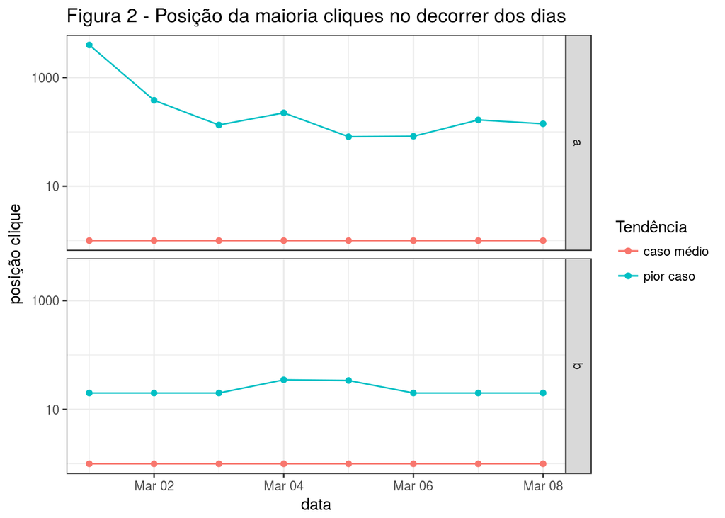

```r
    buscas %>%
        group_by(data = as.Date(session_start_date), group) %>%
        summarise(position_cliked_median = median(na.omit(position_clicked)), position_cliked_max = max(na.omit(position_clicked))) %>%
        ggplot() +
        geom_line(aes(x = data, y = position_cliked_median, colour = "caso médio")) + geom_point(aes(x = data, y = position_cliked_median, colour = "caso médio"))+
        geom_line(aes(x = data, y = position_cliked_max, colour = "pior caso")) + geom_point(aes(x = data, y = position_cliked_max, colour = "pior caso"))+
        labs(y= "posição clique", colour = "Tendência", title="Figura 2 - Posição da maioria cliques no decorrer dos dias") +
        facet_grid(group ~ .) + scale_y_log10()
```

Com base na Figura 2 e a tabela acima, é evidente que a primeira posição é a mais clicada entre os usuários (grupo a e b) em todos os 8 dias avaliados, existindo uma constância nesse aspecto. Além disso, optamos por identificar também os piores casos, onde por meio da Figura 2, é possível perceber que o pior caso entre os dias no grupo a é identificado no dia 01 de março de 2016 (posição acima de 1000) e para o grupo b o piores casos são identificados nos dias 04 e 05 de março de 2016 (posição acima de 10 e abaixo de 1000). Além disso, é perceivel por meio da visualização verificar que no grupo a existe uma maior variação entre os piores casos nos dias. Por fim, no grupo b essa variação é menor, possuindo uma maior constância no que diz respeito ao pior caso do dia.

A grande diferenciação entre os grupos a e b no pior caso pode ser influência da diferentes formas de buscas propostas para cada grupo, analisando de forma mais detalhadas os dados, foi verificado que para o grupo b que a posição 35 foi a máxima escolhida e para o grupo a esta posição foi 3972. No entanto, devido a pouca informação acerca das diferenças entre o site utilizado pelo grupo a e b, não podemos confirmar esta afirmação.

## 4. Taxa de buscas com zero resultados

Para tentar responder a pergunta 3, as sessões foram separadas entre os 8 dias existentes nos dados. Desta forma, a Figura 3 expõe a proporção de pesquisas que tiveram zero resultados em cada dia do estudo, considerando essa proporção nos grupos a e b.

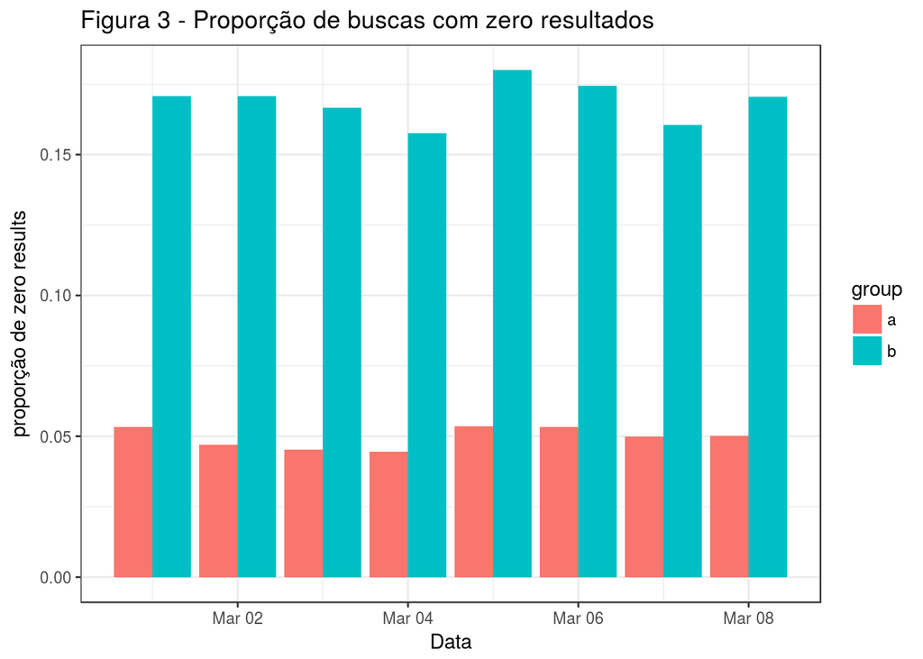

```r
 buscas %>%
        filter(search_index > 0) %>%
        group_by(data = as.Date(session_start_date), group) %>%
        summarise(zero_results = sum(na.omit(results) == 0)/n()) %>%
        ggplot(aes(x = as.Date(data), y = zero_results, fill = group)) +
        geom_col(position = "dodge") +
        scale_x_date('Data', date_labels = "%b %d") +
        labs(y= "proporção de zero results", title="Figura 3 - Proporção de buscas com zero resultados")
```

Ainda nesse contexto, é possível verificar também que a menor proporção de buscas com 0 resultados é no dia 04 de marçõ de 2016 para ambos os grupos.

## 5. Tempo de sessão e número de cliques

De acordo com os dados o número de cliques em cada sessão é representado pelo o número de vezes que usuário acessou um nova página. Com base nesta definição e considerando o tempo da seção em segundo como a diferença entre o primeiro e último eventos da sessão, foi construída a Figura 4, que mostra a relação entre número de cliques e tempo de sessão para cada sessão.

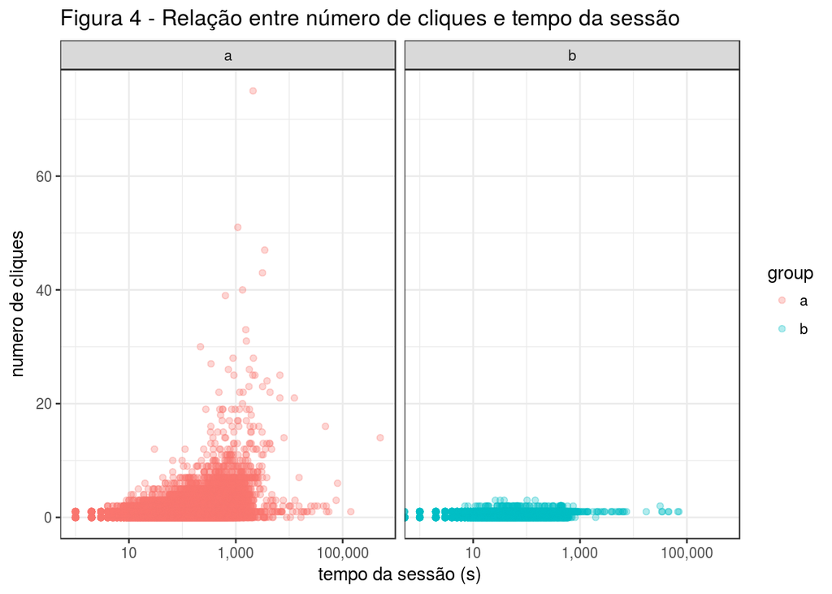

```r
    buscas %>%
        ggplot( aes(x = session_durantion_sec , y = num_clicks, color = group)) +
        geom_point( alpha = 0.3) + scale_x_log10(labels = comma)+
        facet_grid(~ group) +
        labs(x = "tempo da sessão (s)", y = "numero de cliques", title="Figura 4 - Relação entre número de cliques e tempo da sessão")
```

A figura 4 mostra uma alta concentração de sessões com tempo médio de sessão entre 10 e 1000 segundos em ambos os grupos. Já quando em relação aos número de cliques o grupo a possui sua concentração maior entre 0 e 20 cliques e no grupo b este valor fica entre 0 a 3 cliques em sua maior concentração.

Analisando a Figura com enfoque proposto na pergunta 4, não foi possível identificar tal relação, devido a grande dispersão encontrada no grupo a, onde existe sessões com mais de 40 cliques, mas com tempo de sessão entre 1000 a 2000 segundos e existem sessões com tempo de sessão maior de 100.000 segundos e com número de cliques inferior a 20. No grupo b, não foi verificada nenhuma relação nesse contexto, pois é verificável a existência de uma constância no que se refere ao número de cliques variando entre as faixa de valores 0 a 5.